# BDA+CM_2017: Homework 5

This homework assignment is due July 28th 2017 before noon. Submit your results in a zipped archive with name `BDA+CM_HW5_YOURLASTNAME.zip` which includes both Rmarkdown and a compiled version (preferably HTML). Use the same naming scheme for the `*.Rmd` and `*.html` files. All other files, if needed, should start with `BDA+CM_HW5_YOURLASTNAME_` as well. Upload the archive to the Dropbox folder.

Keep your descriptions and answers as short and concise as possible, without reverting to bullet points. **All of the exercises below are required and count equally to the final score if you are taking this course for 6 credit points. If you want 3 credit points for this course, you only need to do the first exercise.**

# Exercise 1: Robust regression

We will look once more at the IQ data from class (plucked from Kruschke’s textbook).

```r
iq_data = readr::read_csv('../data/07_Kruschke_TwoGroupIQ.csv')
head(iq_data)
```

```
## # A tibble: 6 x 2
##   Score      Group
##   <int>      <chr>
## 1   102 Smart Drug
## 2   107 Smart Drug
## 3    92 Smart Drug
## 4   101 Smart Drug
## 5   110 Smart Drug
## 6    68 Smart Drug
```

Here’s a plot of the data to compare the distribution of measured IQ scores in both groups:

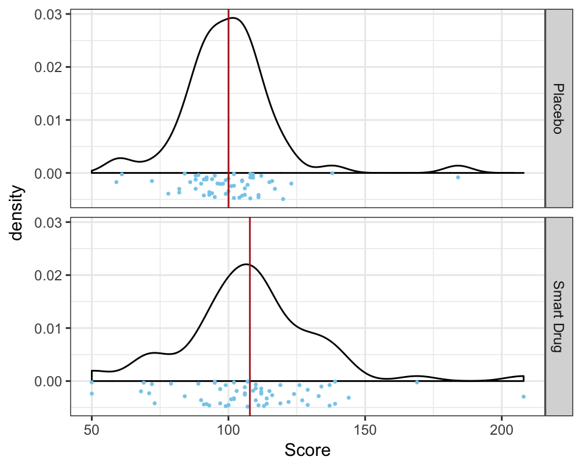

```r
iq_data %>% group_by(Group) %>% mutate(mean_score = mean(Score)) %>%
  ggplot(aes(x = Score)) + geom_density() +
  geom_point(aes(x = Score,
                 y = 0 - runif(nrow(iq_data), 0, 0.005)),
             color = "skyblue", size = 0.5) +
  facet_grid(Group ~ .) +
  geom_vline(aes(xintercept = mean_score), color = "firebrick")
```

The graphs show the estimated densities (black lines), a jittered scatter plot of each data point (blue dots) and the means (red vertical lines) of both control and treatment group. We see that there are quite some outliers, which a Gaussian noise model might not be ideally suited to deal with. For this reason, we will look at two linear regression models, both of which predict metric variable `Score` in terms of categorical variable `Group`. One model has a Gaussian noise model, the other uses a $t$-distribution instead.

The Gaussian noise model is this:

$\begin{align*} y_{\text{pred}} & = \beta_0 + \beta_1 x & \ \ \ \ \ \ \ \ \ \ \ \ \ \ y & \sim \mathcal{N}(\mu = y_{\text{pred}}, \sigma_{err}) \\ \beta_0 & \sim \mathcal{N}(100, 15) & \ \ \ \ \ \ \ \ \ \ \ \ \ \ \frac{1}{\sigma_{err}^2} & \sim \text{Gamma}(0.1,0.1) \\ \beta_1 & \sim \mathcal{N}(0, 30) \end{align*}$

Here’s the JAGS code for the Gaussian model, which we used in class:

```r
# specify model
modelString = "
model{
 sigma_e = 1/sqrt(tau_e)
 tau_e ~ dgamma(0.1,0.1)
 b0 ~ dnorm(100, 1/15^2)
 b1 ~ dnorm(0, 1/30^2)
 for (i in 1:k){
   yPred[i] = b0 + b1 * x[i]
   y[i] ~ dnorm(yPred[i], tau_e)
 }
}
"
# prepare data for JAGS
dataList = list(y = iq_data$Score,
                x = ifelse(iq_data$Group == "Placebo", 0, 1),
                k = nrow(iq_data))

# set up and run model
params <- c('b0', "b1", "sigma_e")
jagsModel = jags.model(file = textConnection(modelString),
                       data = dataList,
                       n.chains = 3, quiet = TRUE)
update(jagsModel, 5000) # 5000 burn-in samples
codaSamples = coda.samples(jagsModel,
                           variable.names = params,
                           n.iter = 20000)

ggmcmc::ggs(codaSamples) %>%
  group_by(Parameter) %>%
  summarize(HDI_lo = coda::HPDinterval(as.mcmc(value))[1],
            mean = mean(value),
            HDI_hi = coda::HPDinterval(as.mcmc(value))[2])
```

```
## # A tibble: 3 x 4
##   Parameter     HDI_lo       mean    HDI_hi
##      <fctr>      <dbl>      <dbl>     <dbl>
## 1        b0 94.4351031 100.113340 105.78655
## 2        b1 -0.1720315   7.672494  15.60908
## 3   sigma_e 19.5371152  22.309443  25.25697
```

1. Based on these results from parameter inference, would you conclude that it is credible that there is a difference between control and treatment group? (Hint: is some relevant parameter’s 95% HDI credibly different from some relevant value?)
2. Implement the following robust regression model (Hints: you only need to change a few lines of code in the script above; the exponential distribution with shape parameter $\frac{1}{30}$ in JAGS is `dexp(1/30)`; it is not entirely improbable that Kruschke’s textbook contains all and exactly the information you need):

$\begin{align*} y_{\text{pred}} & = \beta_0 + \beta_1 x & \ \ \ \ \ \ \ \ \ \ \ \ \ \ y & \sim \mathcal{t}(\mu = y_{\text{pred}}, \sigma_{err}, \nu) \\ \beta_0 & \sim \mathcal{N}(100, 15) & \ \ \ \ \ \ \ \ \ \ \ \ \ \ \frac{1}{\sigma_{err}^2} & \sim \text{Gamma}(0.1,0.1) \\ \beta_1 & \sim \mathcal{N}(0, 30) & \nu - 1 & \sim \text{Exponential}(1/30) \end{align*}$

3. What do you infer now based on parameter estimation about whether it is credible that there is a difference between control and treatment group?

# Exercise 2: Mixed effects regression

The goal of this exercise is to demonstrate how the inclusion of mixed effects can lead to more conservative conclusions. We consider the self-paced reading data from the study on Chinese relative clauses again. But we will rig the data slightly:

```r
rt_data = readr::read_delim('../data/08_gibsonwu2012data.txt', delim = " ") %>%
  filter(region == "headnoun") %>%
  mutate(so = ifelse(type == "subj-ext", "-1", "1")) %>%
  select(subj, item, so, rt) %>%
  mutate(rt_rigged = ifelse(subj <= 10 & so == 1, rt*0.75, rt * 0.85)) # rigging the data!
```

1. Calculate a simple linear regression model with only fixed effects, using the `brms` package. Regress rigged log-reading time against condition factor `so`, just as we did in class for the orginal, non-rigged data. As we did in class, use the default (flat/improper) priors of the `brms` package. Inspect the 95% HDI for parameter `so` and check whether there is a credible effect of relative clause type. (Let us not worry about ROPEs for the sake of clarity; just look at whether the relevant value is in the 95% HDI.)
2. Let’s do the same parameter inference and 95% HDI check for the regression model with the maximal mixed effects structure (the last one from class). What do you conclude now about whether it’s credible that there is an effect of relative clause type?
3. If everything went well (there can be stochastic fluctuations!) the parameter estimate for the hierarchical model is more conservative. Try to explain in simple and rough terms why the addition of mixed effects (whatever they are) can have such an effect.
4. Compare the fitted models using leave-one-out cross-validation. Use function `loo::loo(model_1, model_2)` from the `loo` package. This function returns the loo-values as discussed in class multiplied by $-2$ (thus making the loo score play in the same ballpark as standard information criteria). Interpret the outcome of this model comparison. Which model is better? (Be mindful about whether bigger numbers are better or smaller ones are.) Check the estimated standard error of the loo-IC scores, as returned by the `loo` function, and validate whether the result of the model comparison is trustworthy given the `loo` function’s estimation method. (There may be warning messages about slightly high diagnostic values, which you would normally take very serious (read the [paper](https://arxiv.org/abs/1507.04544) that goes with the `loo` package if you can!), but for this exercise you may pass them over.)